# Question

Determine $z$ such that $P(|Z|>z)=0.38$. In other words, how far from 0 should boundaries be set such that 38% of standard normal values are outside those boundaries? (Answers within 0.01 from the correct value will be marked correct.)

# Solution

Start with a sketch. The total two-tail area is 0.38, so each tail has half that area.

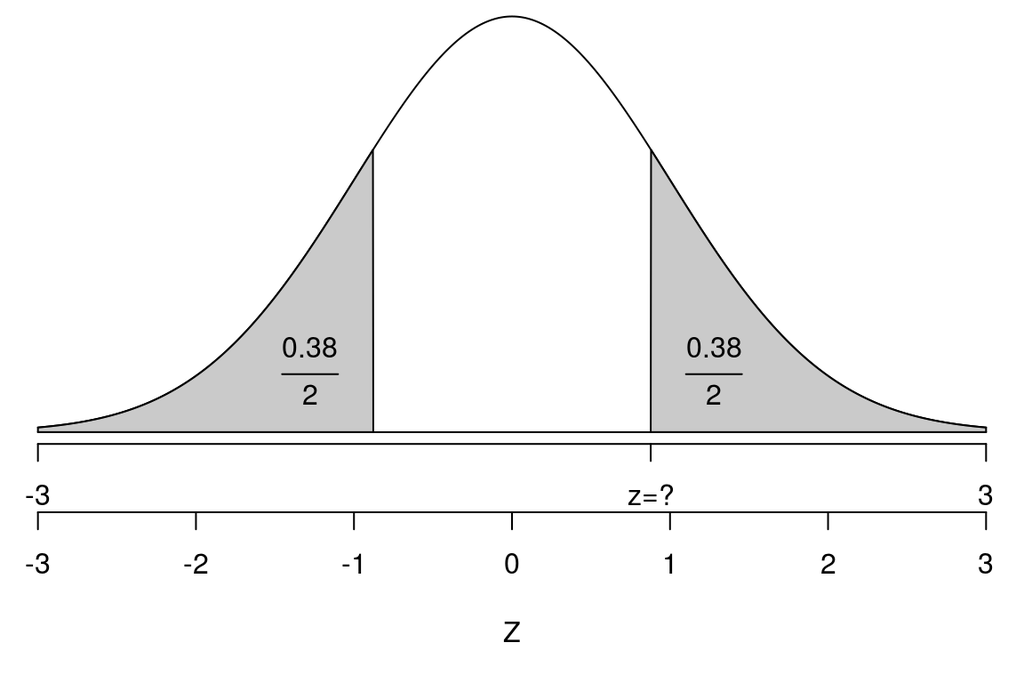

**Method 1:** Determine the area of each tail and the center. Both tails have the same area, and all three areas add to 1. Thus,
$$P(Z>z) = \frac{0.38}{2} = 0.19$$

$$P(Z<-z) = \frac{0.38}{2} = 0.19$$

$$\begin{aligned}
P(|Z|<z) &= 1-P(|Z|>z) \\
&= 1-0.38 \\
&= 0.62
\end{aligned}$$

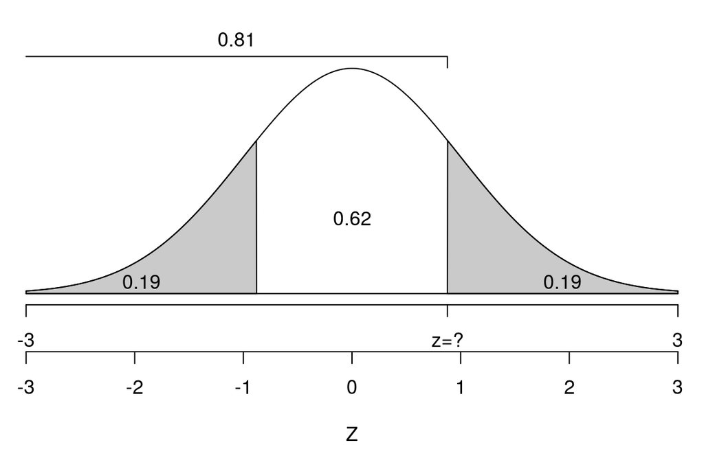

Find the left area.

$$\begin{aligned}
P(Z<z) &= 0.19+0.62 \\
&= 0.81
\end{aligned}$$

You should go to your $z$-table and find the $z$-score with the left area closest to 0.81.

| $z$ | $P(Z<z)$ |
| --- | --- |
| 0.85 | 0.8023 |
| 0.86 | 0.8051 |
| **0.87** | **0.8078** |
| **0.88** | **0.8106** |
| 0.89 | 0.8133 |
| 0.9 | 0.8159 |

It turns out the exact answer is 0.8778963, which could be found by using an inverse normal function. Like InvNorm(0.81) on a TI calculator, Norm.Inv(0.81) on a spreadsheet, or qnorm(0.81) in R.

But, because we are using the $z$-table, I will accept either 0.87 or 0.88. (Or, really anything within 0.011 of 0.8778963.)

**Method 2:** Another way to get 0.81 is by subtracting half of 0.38 from 1.
$$P(Z<z) ~=~ 1-\frac{0.38}{2}~=~ 1-0.19 ~=~ 0.81$$

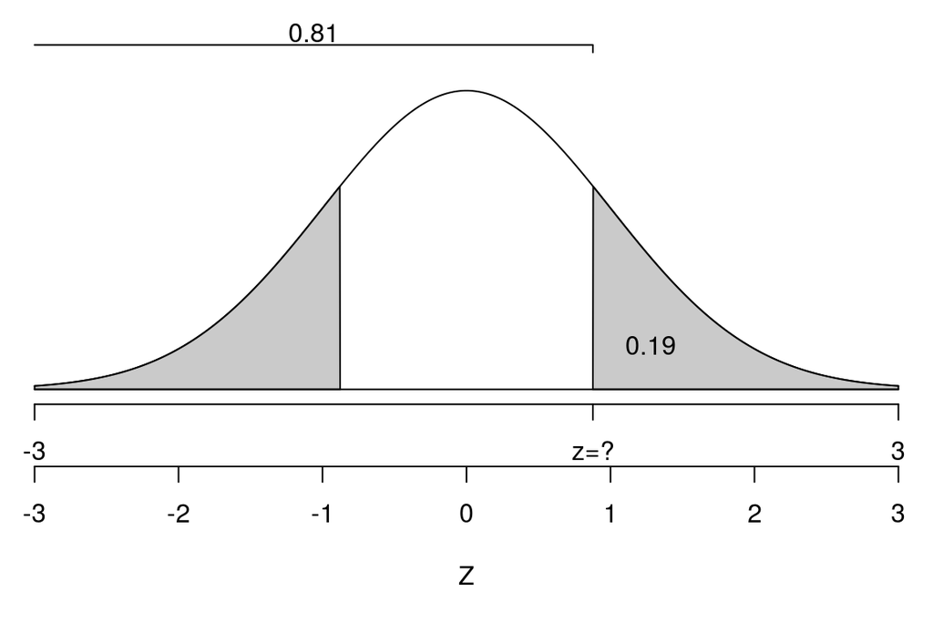

Then, use the table.

# Meta-information

extype: num exsolution: 0.8778963 exname: Get z from twotail area extol: 0.011